# Data Exploration Project

Jasmine P

2022-05-1

## Libraries

```r
library(tidyverse)
library(dplyr)
library(lubridate)
library(car)
library(jtools)
library(tidyr)
library(purrr)
library(haven)
library(stringr)
library(fixest)
```

## Reading in the Google Trends data

```r
ggtrend <- list.files(path = "Lab3_Rawdata", pattern = "trends_up_to_",full.names = TRUE) %>% map_df(read_csv)
```

## Aggregating the Google Trends data

```r
# Getting date data
ggtrend <- ggtrend %>%
  mutate(date = ymd(str_sub(monthorweek,1,10)))
# Aggregating
ggtrend_grouped <- ggtrend %>%
  group_by(schname,keyword) %>%
  mutate(index_sd = (index - mean(index, na.rm = TRUE))/ sd(index,na.rm = TRUE)) %>%
  group_by (date = floor_date(date, "month"))
```

## Reading in the Scorecard data

```r
data <- read.csv("Lab3_Rawdata/Most+Recent+Cohorts+(Scorecard+Elements).csv")
id_name_link <- read.csv("Lab3_Rawdata/id_name_link.csv")
```

## Merge in the Scorecard data

```r
# Get rid of school names that show up more than once
id_name_link <- id_name_link %>%
  group_by(schname) %>%
  mutate(N = n()) %>%
  filter(N == 1)
# Join ggtrend to id_name_link
trendID <- id_name_link %>%
  left_join(ggtrend_grouped, by = 'schname')
# Join unitid and opeid
names(trendID)[names(trendID)=='unitid'] <- 'UNITID'
names(trendID)[names(trendID)=='opeid'] <- 'OPEID'
trendScore <- trendID %>%
  inner_join(data, by = c('UNITID' = 'UNITID','OPEID' = 'OPEID'))
```

## The Analysis

The goal of this analysis is to answer the research question: Among colleges that predominantly grant bachelor’s degrees, did the release of the Scorecard shift student interest to high-earnings colleges relative to low-earnings ones (as proxied by Google searches for keywords associated with those colleges)?

There is a variable in the Scorecard with information about the median earnings of graduates ten years after graduation for each college. According to askwonder.com, the average salary for individuals with five to nine years of experience is $63,235. We can define “high-earning” and “low-earning” colleges by creating a binary variable for earning above and below $60k(High - Low).

After cleaning, these are the variables used in this analysis: 1. Date 2. ID 3. Median earnings of students 4. High/Low earnings 5. Standardized trending index

```r
# Convert the earnings to numeric
trendScore$md_earn_wne_p10.REPORTED.EARNINGS = as.numeric(as.character(trendScore$md_earn_wne_p10.REPORTED.EARNINGS))
# Create binary variables for High/Low income
trendScore$Earnings <- ifelse(trendScore$md_earn_wne_p10.REPORTED.EARNINGS >= 60000, "High", "Low")
# Filter out the colleges that predominantly grant bachelor's degrees
trendScore <- trendScore %>% filter(PREDDEG == 3 , na.rm = TRUE)
#Keep only necessary columns
trendScore_rec <- trendScore %>%
  select(UNITID, OPEID, schname,keyword, date,md_earn_wne_p10.REPORTED.EARNINGS,Earnings, index_sd)
# Remove missing values
trendScore_rec <- drop_na(trendScore_rec)
```

Based on the p-value, we reject the null hypothesis that there’s no difference between the treated group and control group after the treatment went into effect. We can assume that there’s no statistically significant evidence that the the treated and control group had the same search level in the post-treatment period.

```r
#Create treatment group and control group. The date is set as "2015-10-01" since Scorecard was released on September 15th 2015.

trendScore_rec <- trendScore_rec %>%
  mutate(treated = md_earn_wne_p10.REPORTED.EARNINGS >= 60000, post_treatment = date >= as.Date("2015-10-01"))

#Build regression
reg <- feols(index_sd ~treated* post_treatment, data = trendScore_rec)
etable(reg)
```

```
##                                                  reg
## Dependent Var.:                             index_sd
##
## (Intercept)                       0.0422*** (0.0012)
## treatedTRUE                         -0.0056 (0.0046)
## post_treatmentTRUE               -0.2595*** (0.0029)
## treatedTRUE x post_treatmentTRUE   0.0348** (0.0115)
## ________________________________ ___________________
## S.E. type                                        IID
## Observations                                 909,886
## R2                                           0.00909
## Adj. R2                                      0.00908
## ---
## Signif. codes: 0 '***' 0.001 '**' 0.01 '*' 0.05 '.' 0.1 ' ' 1
```

To further answer the research question, I created a line chart. This chart is divided into two period, separating by the vertical line. From the vertical line is the post treatment, where Scorecard was released.

```
## No summary function supplied, defaulting to `mean_se()`
```

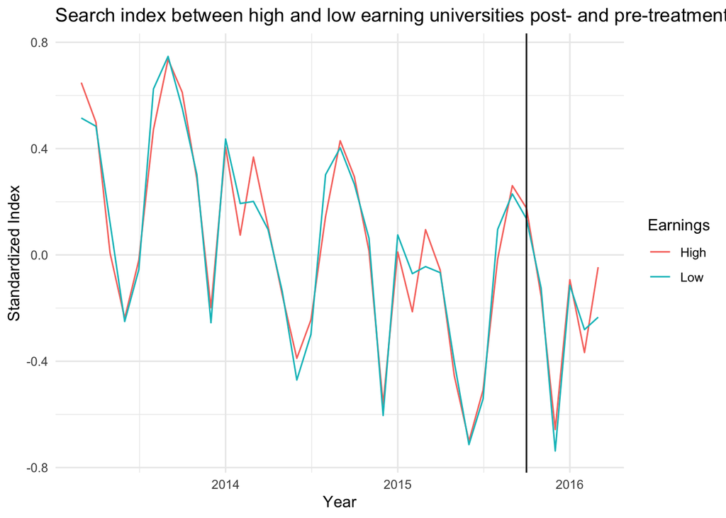

The release of Scorecard led people to search more often for “high-earning” universities. People began looking for “high-earning” institutions after the introduction of Scorecard. However, there isn’t much of a shift in the way people search. The Scorecard had just a little impact on search trends and aggregated search activity.